# Cartographie Sémantique et Analyse des Publications de la FSBM par NLP & Web Scraping

**Faculté des Sciences Ben M'Sik (FSBM) — Université Hassan II de Casablanca**

Ce notebook raconte le pipeline de bout en bout : liste des chercheurs (PDF) → profils Google Scholar → publications → abstracts → nettoyage → embeddings **zembed-1** → index FAISS → recherche sémantique → cartographie.

> **Règle du projet :** aucune donnée scientifique n'est inventée. Toute valeur introuvable reste `None`/`NaN` avec un statut qui explique pourquoi. Ce notebook **lit** les résultats produits par les scripts `scripts/01…08` ; chaque section signale clairement si une étape préalable n'a pas encore été exécutée.

## 1. Introduction

L'objectif est d'évaluer et de valoriser la production scientifique des enseignants-chercheurs de la FSBM en construisant un jeu de données propre, exploitable par des techniques de NLP.

## 2. Objectif

1. Identifier les chercheurs FSBM (source de référence : `Membres FSBM.pdf`) ;
2. retrouver **prudemment** leurs profils Google Scholar ;
3. collecter publications, métriques et abstracts (Scholar puis Crossref / OpenAlex / Semantic Scholar) ;
4. nettoyer, dédupliquer, valider ;
5. encoder titre + abstract avec **zembed-1** ;
6. offrir une recherche sémantique de publications et de chercheurs ;
7. produire une cartographie sémantique et des analyses descriptives.

## 3. Architecture du pipeline

```
graph TD
A[PDF Membres FSBM] --> B[Extraction chercheurs]
B --> C[Google Scholar]
C --> D[Publications]
D --> E[Enrichissement abstracts]
E --> F[Data Cleaning]
F --> G[zembed-1]
G --> H[FAISS]
H --> I[Recherche sémantique]
G --> J[Cartographie sémantique]
```

| Étape | Script | Sortie principale |
| --- | --- | --- |
| 0 | `01_extract_members.py` | `data/raw/chercheurs_fsbm.csv` |
| 1 | `02_scrape_scholar.py` | `data/raw/scholars_raw.json`, `publications_raw.json` |
| 2 | `03_clean_data.py` | `data/processed/*` + rapport qualité |
| 3 | `04_generate_embeddings.py` | `data/vector_store/embeddings.npy` |
| 3 | `05_build_index.py` | index FAISS |
| 3 | `06_demo_search.py` | résultats de recherche |
| + | `07_semantic_map.py`, `08_descriptive_analysis.py` | figures |

```python
import os, sys, json, warnings
from pathlib import Path

ROOT = Path.cwd().resolve()
while not (ROOT / "config" / "settings.yaml").exists() and ROOT != ROOT.parent:
    ROOT = ROOT.parent
sys.path.insert(0, str(ROOT))
warnings.filterwarnings("ignore")

import numpy as np
import pandas as pd
import matplotlib.pyplot as plt
from IPython.display import Image, Markdown, display

from src.utils.config import load_settings, resolve_path, get_env
from src.utils.io import read_json

pd.set_option("display.max_colwidth", 80, "display.width", 160)
settings = load_settings(os.environ.get("FSBM_SETTINGS"))   # FSBM_SETTINGS : config alternative (optionnel)
RAW, PROC = resolve_path(settings, "raw_dir"), resolve_path(settings, "processed_dir")
STORE, FIG, REP = (resolve_path(settings, k) for k in ("vector_store_dir", "figures_dir", "reports_dir"))


def available(*paths, hint="") -> bool:
    "Vrai si tous les fichiers existent ; sinon explique quelle étape lancer."
    missing = [Path(p).name for p in paths if not Path(p).exists()]
    if missing:
        print(f"⚠ Fichier(s) absent(s) : {missing}. {hint}")
    return not missing


print("Racine du projet :", ROOT)
```

```
Racine du projet : C:\Users\User\Desktop\DL\fsbm-semantic-publications
```

## 4. Chargement de la liste FSBM

Le PDF `Membres FSBM.pdf` est la **source de référence** (colonnes : Etablissement, Enseignant Chercheur, Laboratoire, Equipe, Type Membre). `scripts/01_extract_members.py` l'extrait avec `pdfplumber` par coordonnées de mots (impression d’une page web, contrôle d’intégrité 1…N et total « Records »), avec repli (tableaux → repli texte), normalise les noms (`DRISS.BOUGGAR` → `Driss Bouggar`, valeur originale conservée) et crée un identifiant stable (`fsbm_driss_bouggar`). Les membres d'autres établissements (ENCG, FSJESAS…) restent dans le fichier brut.

```python
members = None
if available(RAW / "chercheurs_fsbm.csv", hint="Lancez : python scripts/01_extract_members.py"):
    members = pd.read_csv(RAW / "chercheurs_fsbm.csv")
    display(members.head(10))
    print(members.shape)
```

|  | chercheur_id | chercheur_source_name | nom_complet | etablissement | laboratoire | equipe | type_membre | is_duplicate_row | row_number | source_page |
| --- | --- | --- | --- | --- | --- | --- | --- | --- | --- | --- |
| 0 | fsbm_abdelhak_chakli | ABDELHAK.CHAKLI | Abdelhak Chakli | FSBM | Laboratoire de Traitement de l'Information | Télécommunications et Systèmes Automatiques | Membre Permanent(e) | False | 1 | 1 |
| 1 | fsbm_abdelhakim_alali | ABDELHAKIM.ALALI | Abdelhakim Alali | FSBM | Laboratoire de Traitement de l'Information | Systèmes Électroniques Intelligents | Membre Permanent(e) | False | 2 | 1 |
| 2 | fsbm_abdellatif_slimani | ABDELLATIF.SLIMANI | Abdellatif Slimani | FSBM | Laboratoire de Traitement de l'Information | Télécommunications et Systèmes Automatiques | Membre Permanent(e) | False | 3 | 1 |
| 3 | fsbm_abdelmoghit_zaarane | Abdelmoghit.ZAARANE | Abdelmoghit Zaarane | FSBM | Laboratoire de Traitement de l'Information | Systèmes Électroniques Intelligents | Membre Permanent(e) | False | 4 | 1 |
| 4 | fsjesas_ahmed_eddaoui | AHMED.EDDAOUI | Ahmed Eddaoui | FSJESAS | Laboratoire de Traitement de l'Information | Intelligence artificielle et Géoinformatique appliquées | Membre Permanent(e) | False | 5 | 1 |
| 5 | flshbm_amal_yalid | AMAL.YALID | Amal Yalid | FLSHBM | Laboratoire de Traitement de l'Information | Intelligence artificielle et Géoinformatique appliquées | Membre Permanent(e) | False | 6 | 1 |
| 6 | fsbm_asmaa_drighil | ASMAA.DRIGHIL | Asmaa Drighil | FSBM | Laboratoire de Traitement de l'Information | Matériaux, Energies Renouvelables et Smart Technologies | Membre Permanent(e) | False | 7 | 1 |
| 7 | fsbm_asmae_guennoun | ASMAE.GUENNOUN | Asmae Guennoun | FSBM | Laboratoire de Traitement de l'Information | Matériaux, Energies Renouvelables et Smart Technologies | Membre Permanent(e) | False | 8 | 1 |
| 8 | fsbm_aziza_elbakali | AZIZA.ELBAKALI | Aziza Elbakali | FSBM | Laboratoire de Traitement de l'Information | Systèmes Électroniques Intelligents | Membre Permanent(e) | False | 9 | 1 |
| 9 | fsbm_elmostafa_tace | ELMOSTAFA.TACE | Elmostafa Tace | FSBM | Laboratoire de Traitement de l'Information | Matériaux, Energies Renouvelables et Smart Technologies | Membre Permanent(e) | False | 10 | 1 |

```
(215, 10)
```

## 5. Exploration des chercheurs

```python
if members is not None:
    from src.data.extract_fsbm_members import summarize_members
    stats = summarize_members(members, settings["data"]["institution"])
    for key in ("lignes_extraites", "personnes_uniques_total", "membres_fsbm_uniques", "etablissements",
                "laboratoires_fsbm", "equipes_fsbm", "lignes_doublons_exacts", "personnes_avec_plusieurs_affectations",
                "valeurs_manquantes"):
        print(f"{key:40s}: {stats[key]}")
    display(pd.Series(stats["chercheurs_par_laboratoire"], name="chercheurs").to_frame())
```

```
lignes_extraites                        : 215
personnes_uniques_total                 : 215
membres_fsbm_uniques                    : 207
etablissements                          : {'FSBM': 207, 'FSJESAS': 3, 'FLSHBM': 2, 'ENCG': 2, 'FMPC': 1}
laboratoires_fsbm                       : 11
equipes_fsbm                            : 42
lignes_doublons_exacts                  : 0
personnes_avec_plusieurs_affectations   : 0
valeurs_manquantes                      : {'etablissement': 0, 'laboratoire': 0, 'equipe': 0, 'type_membre': 0}
```

|  | chercheurs |
| --- | --- |
| Laboratoire d'Analyse, Modélisation et Simulation | 25 |
| Laboratoire de Physique de la Matière Condensée | 23 |
| Laboratoire d'Ecologie et d'Environnement | 23 |
| Laboratoire Biologie et Santé | 21 |
| Géosciences, Géomatique et Environnement | 20 |
| Laboratoire de Chimie Analytique et Moléculaire | 17 |
| Laboratoire d’Ingénierie et de Matériaux | 17 |
| Laboratoire de Chimie Physique des Matériaux Appliqués | 16 |
| Laboratoire de Traitement de l'Information | 15 |
| Laboratoire d’Intelligence Artificielle et Systèmes | 15 |
| Technologie de l'Information et Modélisation | 15 |

## 6. Scraping Google Scholar

`scripts/02_scrape_scholar.py` collecte, pour chaque chercheur FSBM :

- **conformité `robots.txt`** : Google Scholar autorise les profils (`/citations?user=ID`) mais interdit la recherche d'auteurs par nom et la pagination (`cstart=`). Par défaut, chaque URL est vérifiée avant envoi et les profils sont identifiés par un **Scholar ID renseigné à la main** (`--init-overrides` génère le modèle `data/raw/scholar_overrides.csv`) ; `--allow-author-search` réactive la recherche par nom, sous la responsabilité de l'utilisateur ;
- **résolution prudente du profil** (recherche par nom, si activée) : score de confiance (`profile_match_confidence`) combinant nom, affiliation (« Faculty of science Ben M'Sik », « Hassan II »), domaine d'email `univh2c.ma`, laboratoire et co-auteurs FSBM. Le nom seul plafonne à 0,40. Statuts : `matched`, `ambiguous`, `not_found`, `blocked`, `error`. Les cas ambigus sont exportés pour **vérification manuelle** (`data/raw/scholar_candidates_review.csv`) ;
- **robustesse** : délai aléatoire, backoff exponentiel, retries limités, cache par chercheur, checkpoint après chaque chercheur, reprise (`--resume`). En cas de CAPTCHA/429 : **arrêt propre**, aucune tentative de contournement ;
- **enrichissement** des abstracts : Scholar → Crossref → OpenAlex → Semantic Scholar (garde-fou sur la similarité du titre).

```
python scripts/02_scrape_scholar.py --init-overrides                              # modèle des Scholar ID
python scripts/02_scrape_scholar.py --limit-researchers 3 --max-publications 10   # test
python scripts/02_scrape_scholar.py --resume                                      # exécution complète / reprise
```

```python
scholars = pubs_raw = None
if available(RAW / "scholars_raw.json", RAW / "publications_raw.json", hint="Lancez : python scripts/02_scrape_scholar.py"):
    scholars = pd.DataFrame(read_json(RAW / "scholars_raw.json"))
    pubs_raw = pd.DataFrame(read_json(RAW / "publications_raw.json"))
    print("Statuts de profil Scholar :")
    display(scholars["scholar_profile_status"].value_counts().to_frame())
    print("Statut de collecte :")
    display(scholars["collection_status"].value_counts().to_frame())
    print("Confiance d'appariement (profils matched) :")
    display(scholars.loc[scholars.scholar_profile_status == "matched", "profile_match_confidence"].describe().to_frame().T)
    amb = scholars[scholars.scholar_profile_status == "ambiguous"]
    if len(amb):
        print(f"{len(amb)} profil(s) ambigu(s) à vérifier manuellement (data/raw/scholar_candidates_review.csv)")
    print("Publications brutes :", pubs_raw.shape)
    if len(pubs_raw):
        display(pubs_raw[["chercheur_id", "titre", "annee", "citations", "abstract_status", "scrape_status"]].head())
```

```
Statuts de profil Scholar :
```

| scholar_profile_status | count |
| --- | --- |
| matched | 83 |

```
Statut de collecte :
```

| collection_status | count |
| --- | --- |
| complete | 79 |
| error | 4 |

```
Confiance d'appariement (profils matched) :
```

|  | count | mean | std | min | 25% | 50% | 75% | max |
| --- | --- | --- | --- | --- | --- | --- | --- | --- |
| profile_match_confidence | 83.0 | 0.999277 | 0.004628 | 0.97 | 1.0 | 1.0 | 1.0 | 1.0 |

```
Publications brutes : (1764, 30)
```

|  | chercheur_id | titre | annee | citations | abstract_status | scrape_status |
| --- | --- | --- | --- | --- | --- | --- |
| 0 | fsbm_abdelhakim_alali | Recovery of household waste by generation of biogas as energy and compost as... | 2021.0 | 44 | found | detail_ok |
| 1 | fsbm_abdelhakim_alali | Emerging Technologies in Learning: A Bibliometric Analysis of Technology Int... | 2025.0 | 11 | found | detail_ok |
| 2 | fsbm_abdelhakim_alali | Ultrasound imaging: beamforming techniques | 2020.0 | 9 | found | detail_ok |
| 3 | fsbm_abdelhakim_alali | V-net performances for 2D ultrasound image segmentation | 2022.0 | 8 | found | detail_ok |
| 4 | fsbm_abdelhakim_alali | Modeling and simulation of multiprocessor systems MPSoC by SystemC/TLM2 | 2014.0 | 8 | found | detail_ok |

## 7. Qualité des données

Le rapport est produit par `scripts/03_clean_data.py` (`outputs/reports/data_quality_report.json`). Les pourcentages décrivent **le dataset collecté** — pas la production totale de la FSBM.

```python
if available(REP / "data_quality_report.json", hint="Lancez : python scripts/03_clean_data.py"):
    report = read_json(REP / "data_quality_report.json")
    for k, v in report.items():
        print(f"{k:34s}: {v}")
```

```
chercheurs_fsbm_dans_pdf          : 207
chercheurs_avec_scholar_id        : 86
chercheurs_fsbm                   : 86
chercheurs_par_statut_scholar     : {'matched': 83, 'pending': 3}
chercheurs_par_source_de_donnees  : {'openalex': 74, 'none': 7, 'google_scholar': 5}
pct_chercheurs_sans_scholar       : 3.5
publications_uniques              : 1591
liens_chercheur_publication       : 1728
doublons_fusionnes                : 171
publications_avec_doi             : 1522
pct_publications_avec_doi         : 95.7
abstracts_recuperes               : 1122
pct_publications_sans_abstract    : 29.5
abstracts_par_statut              : {'found': 1108, 'not_found': 466, 'too_short': 9, 'truncated': 5, 'api_error': 3}
abstracts_par_source              : {'openalex': 987, '(aucune)': 469, 'semantic_scholar': 74, 'google_scholar': 40, 'crossref': 21}
embedding_source_prevue           : {'title_abstract': 1113, 'title_only': 478}
publications_sans_annee           : 1
erreurs_scraping                  : {'details_publications_en_erreur': 0, 'chercheurs_en_erreur_ou_bloques': 4}
erreurs_validation                : 0
nettoyage                         : {'raw_records': 1764, 'records_without_title_dropped': 2, 'records_outside_target_institution': 0, 'records_after_cleaning': 1762, 'unique_articles': 1591, 'duplicates_merged': 171, 'links': 1728, 'researchers_in_pdf': 207, 'researchers_with_scholar_id': 86}
```

## 8. Nettoyage

- texte : Unicode NFC, suppression HTML/JATS, caractères de contrôle, espaces multiples ; **symboles scientifiques conservés** (α, µ, ±, °) ;
- deux versions de l'abstract : `abstract` (brut, jamais modifié) et `abstract_clean` (minuscules, sans étiquette « Abstract », sans « … » de troncature) ;
- **pas de suppression de stop-words ni de stemming** : les modèles d'embeddings modernes exploitent la phrase entière ;
- dates → ISO à la précision connue (`date_precision` : day/month/year) ; métriques négatives, années implausibles, URL invalides → `None` ;
- déduplication : DOI normalisé → titre normalisé + année → flou prudent (jamais deux DOI différents, jamais « Part I » / « Part II »).

```python
from src.preprocessing.text_cleaner import clean_abstract_for_nlp
from src.preprocessing.data_cleaner import parse_publication_date

raw_example = "<jats:p>Abstract: We STUDY   CO2 capture at 25 °C   in Zeolites…</jats:p>"
print("brut :", raw_example)
print("clean:", clean_abstract_for_nlp(raw_example))
for d in ["2021/1/1", "2021/3", "2019", "March 5, 2018", None]:
    print(f"{d!s:15} ->", parse_publication_date(d))
```

```
brut : <jats:p>Abstract: We STUDY   CO2 capture at 25 °C   in Zeolites…</jats:p>
clean: we study co2 capture at 25 °c in zeolites
2021/1/1        -> ('2021-01-01', 2021, 'day')
2021/3          -> ('2021-03', 2021, 'month')
2019            -> ('2019', 2019, 'year')
March 5, 2018   -> ('2018-03-05', 2018, 'day')
None            -> (None, None, None)
```

```python
articles = researchers = links = None
if available(PROC / "publications_clean.parquet", PROC / "chercheurs_clean.csv", PROC / "researcher_publications.csv",
             hint="Lancez : python scripts/03_clean_data.py"):
    articles = pd.read_parquet(PROC / "publications_clean.parquet")
    researchers = pd.read_csv(PROC / "chercheurs_clean.csv")
    links = pd.read_csv(PROC / "researcher_publications.csv")
    print(f"{len(articles)} publications uniques | {len(links)} liens chercheur↔publication | {len(researchers)} chercheurs")
    if len(articles):
        print("\nPart de valeurs manquantes (%) :")
        display((articles.isna().mean() * 100).round(1).sort_values(ascending=False).head(10).to_frame("% manquant"))
        row = articles[articles.abstract.notna()].head(1)
        if len(row):
            r = row.iloc[0]
            print("\nabstract brut  :", str(r.abstract)[:200])
            print("abstract_clean :", str(r.abstract_clean)[:200])
```

```
1591 publications uniques | 1728 liens chercheur↔publication | 86 chercheurs

Part de valeurs manquantes (%) :
```

|  | % manquant |
| --- | --- |
| numero | 98.4 |
| volume | 97.9 |
| conference | 97.6 |
| pages | 95.7 |
| scholar_url | 95.2 |
| pdf_url | 66.3 |
| abstract | 29.5 |
| abstract_clean | 29.5 |
| abstract_source | 29.5 |
| publisher | 9.8 |

```
abstract brut  : The title compound, C25H34N2O6, was synthesized from 9α-hydroxyparthenolide (9α-hydroxy-4,8-dimethyl-12-methylene-3,14-dioxatricyclo[9.3.0.02,4]tetradec-7-en-13-one), which was isolated from the
abstract_clean : the title compound, c25h34n2o6, was synthesized from 9α-hydroxyparthenolide (9α-hydroxy-4,8-dimethyl-12-methylene-3,14-dioxatricyclo[9.3.0.02,4]tetradec-7-en-13-one), which was isolated from the
```

## 9. Analyse exploratoire

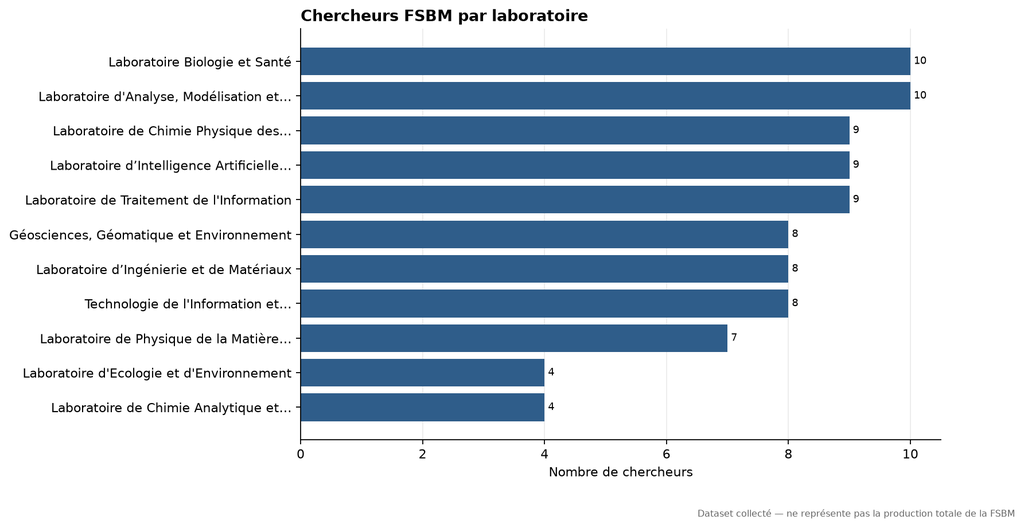

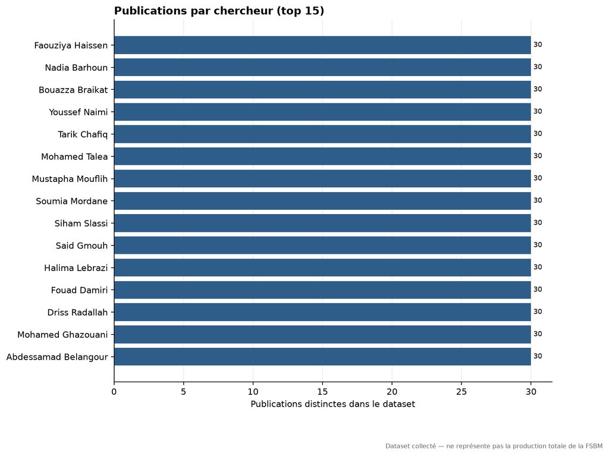

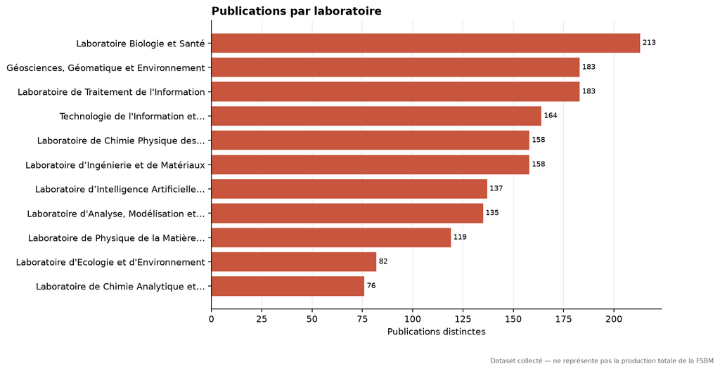

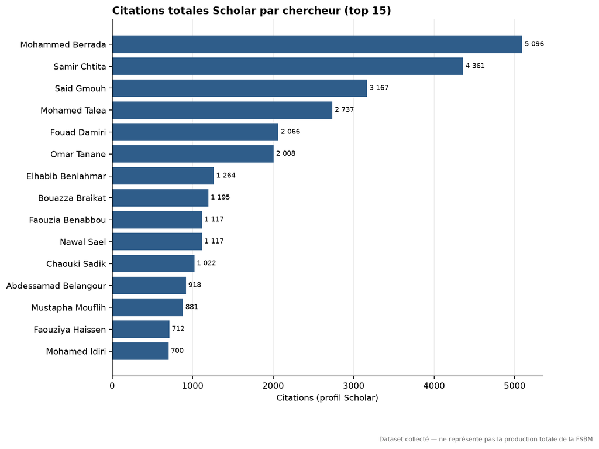

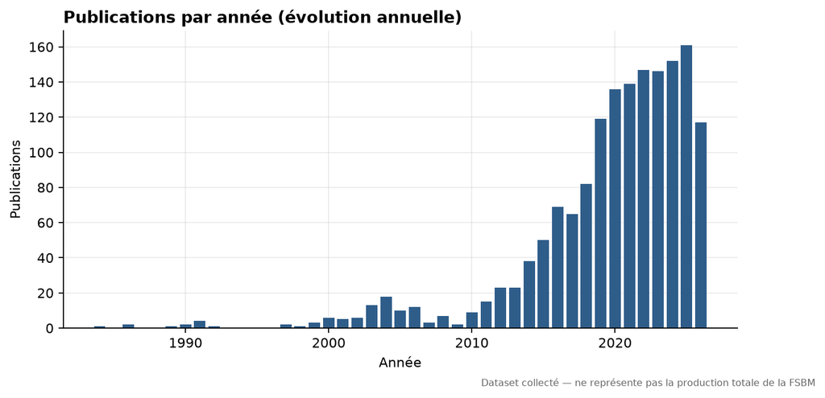

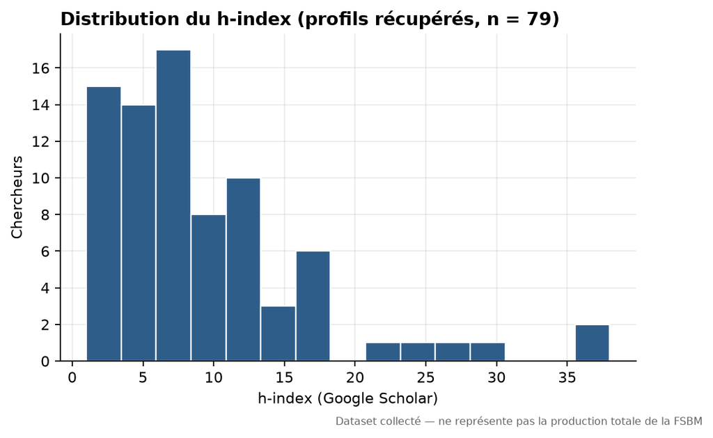

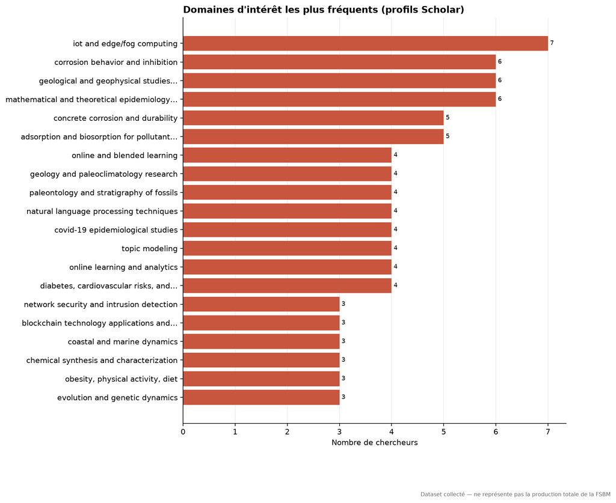

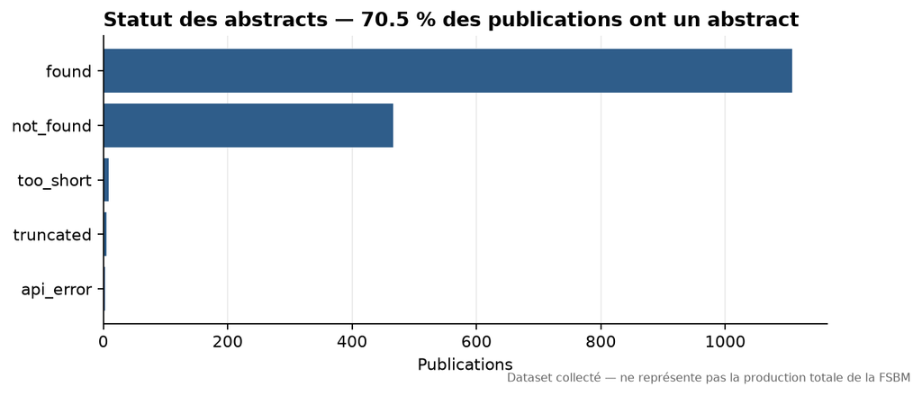

```
⚠ Ces classements décrivent le dataset collecté, pas la production totale de la FSBM.
```

```python
if articles is not None and len(articles):
    from src.analysis.descriptive_analysis import run_descriptive_analysis
    members_all = pd.read_csv(RAW / "chercheurs_fsbm.csv")
    members_all = members_all[members_all["chercheur_id"].isin(researchers["chercheur_id"])]   # mêmes chercheurs que le dataset
    result = run_descriptive_analysis(members_all, researchers, articles, links, FIG, REP, settings["data"]["institution"])
    for path in result["figures"]:
        display(Image(filename=path, width=700))
    print("⚠ Ces classements décrivent le dataset collecté, pas la production totale de la FSBM.")
```

## 10. Préparation NLP

Texte encodé = **titre + abstract nettoyé**. Sans abstract exploitable (absent, ou plus court que `min_abstract_chars`), on encode le titre seul et on l'indique dans `embedding_source` (`title_abstract` | `title_only`).

```python
if articles is not None and len(articles):
    display(articles["embedding_source"].value_counts().to_frame())
    lengths = articles["embedding_text"].dropna().str.len()
    lengths.plot.hist(bins=30, figsize=(7, 3), title="Longueur du texte encodé (caractères)")
    plt.show()
    print(articles["embedding_text"].dropna().iloc[0][:300])
```

[output not shown]

| embedding_source | count |
| --- | --- |
| title_abstract | 1113 |
| title_only | 478 |

```
10α-Hydroxy-13-{[4-(2-hydroxyphenyl)piperazin-1-yl]methyl}-4,9-dimethyl-3,8,15-trioxatetracyclo[10.3.0.02,4.07,9]pentadecan-14-one. the title compound, c25h34n2o6, was synthesized from 9α-hydroxyparthenolide (9α-hydroxy-4,8-dimethyl-12-methylene-3,14-dioxatricyclo[9.3.0.02,4]tetradec-7-en-13-o
```

## 11. zembed-1

Modèle d'embedding **zembed-1** de **ZeroEntropy**. L'éditeur n'accepte plus de nouvelles inscriptions (plus de clé API possible) ; le modèle est cependant publié en **poids ouverts** (`zeroentropy/zembed-1-embedding`, Hugging Face, Apache-2.0, 4 Md de paramètres, base Qwen3-4B), exécutés avec `sentence-transformers`. C'est **le même modèle**, pas un substitut : le client refuse toute autre valeur.

```python
run_info = read_json(STORE / "embedding_run.json")
if run_info:
    print("Dernière génération :", {k: run_info.get(k) for k in ("model", "transport", "runtime", "dimension", "n_embedded", "demo_queries_cached")})
client = None
if (STORE / "embedding_cache.sqlite").exists():
    from src.embeddings.zembed_client import ZEmbedClient
    # les poids (~8 Go) ne sont chargés que si un texte n'est pas déjà dans le cache
    client = ZEmbedClient.from_settings(settings, cache_path=STORE / "embedding_cache.sqlite")
    print("Client zembed-1 prêt — transport :", client.transport, "| entrées en cache :", len(client.cache))
else:
    print("Pas de cache d'embeddings : exécutez le notebook Colab (ou scripts/04) puis copiez les fichiers dans data/vector_store/.")
```

```
Dernière génération : {'model': 'zembed-1', 'transport': 'local', 'runtime': {'weights': 'zeroentropy/zembed-1-embedding', 'revision': 'cf13c81f3274394053d166740294f7eea4586f7a', 'device': 'cuda', 'dtype': 'float16', 'max_seq_length': 512}, 'dimension': 2560, 'n_embedded': 1591, 'demo_queries_cached…
Client zembed-1 prêt — transport : local | entrées en cache : 1594
```

## 12. Vectorisation

```python
vectors = manifest = None
if available(STORE / "embeddings.npy", STORE / "embedding_manifest.csv", hint="Lancez : python scripts/04_generate_embeddings.py"):
    vectors = np.load(STORE / "embeddings.npy")
    manifest = pd.read_csv(STORE / "embedding_manifest.csv")
    print("embeddings :", vectors.shape, vectors.dtype, "| modèle du manifest :", manifest["model"].unique())
    norms = np.linalg.norm(vectors, axis=1)
    print("normes L2 : min %.3f, max %.3f" % (norms.min(), norms.max()))
    from src.search.vector_store import cosine_similarity
    sample = vectors[: min(200, len(vectors))]
    sims = cosine_similarity(sample, sample)
    iu = np.triu_indices_from(sims, k=1)
    plt.figure(figsize=(7, 3))
    plt.hist(sims[iu], bins=40)
    plt.title("Similarités cosinus entre publications (échantillon)")
    plt.show()
```

[output not shown]

```
embeddings : (1591, 2560) float32 | modèle du manifest : <ArrowStringArray>
['zembed-1']
Length: 1, dtype: str
normes L2 : min 1.000, max 1.001
```

## 13. Index FAISS

Vecteurs **normalisés L2** + `IndexFlatIP` = similarité **cosinus exacte**. Sont sauvegardés : l'index, la correspondance `vector_id → article_id` et les métadonnées.

```python
store = None
if available(STORE / "index_info.json", hint="Lancez : python scripts/05_build_index.py"):
    from src.search.vector_store import VectorStore
    store = VectorStore.load(STORE)
    print(json.dumps(store.info, indent=2, ensure_ascii=False))
    if vectors is not None:   # contrôle de cohérence : un vecteur doit se retrouver lui-même avec un score ≈ 1
        hit = store.search(vectors[:1], 1)[0][0]
        print("auto-récupération :", hit[0], "score = %.4f" % hit[1], "(attendu ≈ 1.0000)")
```

```
{
  "backend": "faiss",
  "dimension": 2560,
  "n_vectors": 1591,
  "metric": "cosine (inner product on L2-normalized vectors)",
  "normalized": true,
  "created_at": "2026-09-21T20:55:04+00:00",
  "model": "zembed-1",
  "source_manifest": "embedding_manifest.csv"
}
auto-récupération : art_00001 score = 1.0000 (attendu ≈ 1.0000)
```

## 14. Recherche sémantique

`semantic_search(query, top_k=5)` : requête → zembed-1 (`input_type="query"`) → cosinus → top-K publications. Les chercheurs sont classés en agrégeant les similarités de leurs **3 meilleures publications** retrouvées (score = moyenne, places manquantes = 0), et non par correspondance de mots avec le nom du laboratoire.

```python
engine = None
if store is not None and client is not None and articles is not None:
    from src.search.semantic_search import SemanticSearchEngine
    engine = SemanticSearchEngine(store, client, articles, researchers, links)
    QUERIES = ["deep learning for medical imaging", "natural language processing", "machine learning for cancer diagnosis",
               "renewable energy materials", "environmental pollution"]
    for q in QUERIES:
        display(Markdown(f"**« {q} »**"))
        display(pd.DataFrame([r.to_dict() for r in engine.search(q, settings["search"]["top_k"])])
                [["rank", "score", "titre", "chercheurs", "annee", "journal", "laboratoires", "citations"]])
else:
    print("Recherche non exécutée : il faut l'index (scripts 03-05) ET le cache d'embeddings zembed-1 (notebook Colab / script 04).")
```

**« deep learning for medical imaging »**

|  | rank | score | titre | chercheurs | annee | journal | laboratoires | citations |
| --- | --- | --- | --- | --- | --- | --- | --- | --- |
| 0 | 1 | 0.4499 | Correction to: Systematic Review of Physical, Chemical, and Biological Appro... | [Abdelmjid Abourriche] | 2025 | Sustainable civil infrastructures | [Laboratoire Biologie et Santé] | 0 |
| 1 | 2 | 0.3943 | A deep neural network for detecting the severity level of diabetic retinopat... | [Aziza Elbakali] | 2022 | 2022 2nd International Conference on Innovative Research in Applied Science,... | [Laboratoire de Traitement de l'Information] | 5 |
| 2 | 3 | 0.3864 | Study of optical properties of gold nanoparticles embedded in normal, benign... | [Abdelilah Akouibaa] | 2021 | Journal of Molecular Structure | [Laboratoire d’Ingénierie et de Matériaux] | 15 |
| 3 | 4 | 0.3602 | V-net performances for 2D ultrasound image segmentation | [Abdelhakim Alali] | 2022 | 2022 IEEE 18th International Colloquium on Signal Processing & Applications ... | [Laboratoire de Traitement de l'Information] | 8 |
| 4 | 5 | 0.3474 | Near-optimal stochastic control for radiotherapy treatment in a random cance... | [Driss Bouggar] | 2022 | Systems & Control Letters | [Laboratoire d’Intelligence Artificielle et Systèmes] | 4 |

**« natural language processing »**

|  | rank | score | titre | chercheurs | annee | journal | laboratoires | citations |
| --- | --- | --- | --- | --- | --- | --- | --- | --- |
| 0 | 1 | 0.5410 | Towards a System that Predicts the Category of Educational and Vocational Gu... | [Omar Zahour] | 2024 | Synthesis lectures on engineering, science, and technology | [Technologie de l'Information et Modélisation] | 0 |
| 1 | 2 | 0.5238 | Enhancing Hotel Services Through Sentiment Analysis | [Abderrahmane Daif, Mohamed Ghazouani] | 2024 | Synthesis lectures on engineering, science, and technology | [Technologie de l'Information et Modélisation] | 3 |
| 2 | 3 | 0.4687 | Classifying Figurative Styles in Arabic Using Advanced mT5 Pre-trained Models | [Sanaa Elfilali] | 2025 | Lecture notes in networks and systems | [Laboratoire d’Intelligence Artificielle et Systèmes] | 0 |
| 3 | 4 | 0.4434 | Intelligent Automated Resume Analysis and Ranking System for Profile Recruit... | [Omar Zahour] | 2026 | Communications in computer and information science | [Technologie de l'Information et Modélisation] | 0 |
| 4 | 5 | 0.4312 | Customer Sentiment Analysis in Hotel Reviews Through Natural Language Proces... | [Abderrahmane Daif] | 2023 | International Journal of Advanced Computer Science and Applications | [Technologie de l'Information et Modélisation] | 31 |

**« machine learning for cancer diagnosis »**

|  | rank | score | titre | chercheurs | annee | journal | laboratoires | citations |
| --- | --- | --- | --- | --- | --- | --- | --- | --- |
| 0 | 1 | 0.5739 | Correction to: Systematic Review of Physical, Chemical, and Biological Appro... | [Abdelmjid Abourriche] | 2025 | Sustainable civil infrastructures | [Laboratoire Biologie et Santé] | 0 |
| 1 | 2 | 0.4936 | Study of optical properties of gold nanoparticles embedded in normal, benign... | [Abdelilah Akouibaa] | 2021 | Journal of Molecular Structure | [Laboratoire d’Ingénierie et de Matériaux] | 15 |
| 2 | 3 | 0.4527 | Association of Tumor Necrosis Factor Receptor 1 Promoter Gene Polymorphisms ... | [Halima Lebrazi] | 2020 | BioMed Research International | [Laboratoire Biologie et Santé] | 2 |
| 3 | 4 | 0.4522 | Near-optimal stochastic control for radiotherapy treatment in a random cance... | [Driss Bouggar] | 2022 | Systems & Control Letters | [Laboratoire d’Intelligence Artificielle et Systèmes] | 4 |
| 4 | 5 | 0.4417 | A deep neural network for detecting the severity level of diabetic retinopat... | [Aziza Elbakali] | 2022 | 2022 2nd International Conference on Innovative Research in Applied Science,... | [Laboratoire de Traitement de l'Information] | 5 |

**« renewable energy materials »**

|  | rank | score | titre | chercheurs | annee | journal | laboratoires | citations |
| --- | --- | --- | --- | --- | --- | --- | --- | --- |
| 0 | 1 | 0.5415 | First-Principles Study of Mn-Doped Basno3: Toward High-Performance Perovskit... | [Rhma Adhiri] | 2025 | SSRN Electronic Journal | [Laboratoire d’Ingénierie et de Matériaux] | 0 |
| 1 | 2 | 0.5180 | Unravelling the role of nickel incorporation on the physical properties of C... | [Othmane Daoudi] | 2023 | Journal of Materials Science Materials in Electronics | [Laboratoire de Physique de la Matière Condensée] | 6 |
| 2 | 3 | 0.5081 | Electrodeposition of ZnO thin films at low temperature: effects of depositio... | [Youssef Naimi] | 2024 | Journal of Materials Science Materials in Electronics | [Laboratoire de Traitement de l'Information] | 4 |
| 3 | 4 | 0.5081 | Comprehensive Study of the Structural Properties and Dielectric Responses of... | [Rhma Adhiri] | 2023 | SSRN Electronic Journal | [Laboratoire d’Ingénierie et de Matériaux] | 0 |
| 4 | 5 | 0.5032 | Numerical investigation of electronic, dielectric and optical properties of ... | [Abdelilah Akouibaa] | 2021 | Optical and Quantum Electronics | [Laboratoire d’Ingénierie et de Matériaux] | 14 |

**« environmental pollution »**

|  | rank | score | titre | chercheurs | annee | journal | laboratoires | citations |
| --- | --- | --- | --- | --- | --- | --- | --- | --- |
| 0 | 1 | 0.4075 | Seasonal upwelling drives surface water biogeochemistry with implication for... | [Samia Yousfi] | 2025 | Frontiers in Marine Science | [Laboratoire de Chimie Analytique et Moléculaire] | 7 |
| 1 | 2 | 0.4045 | Traitement Expérimental Par Coagulation Floculation Des Effluents Brutes D’u... | [Abdelmottalib Nahli] | 2019 | European Scientific Journal ESJ | [Laboratoire d'Ecologie et d'Environnement] | 0 |
| 2 | 3 | 0.3833 | Dates Sector in Morocco: Current Situation, Innovations, and Future Challenges | [Soumia Belouafa] | 2025 | Sustainable landscape planning and natural resources management | [Laboratoire Biologie et Santé] | 0 |
| 3 | 4 | 0.3740 | Size-Dependent Antibacterial, Antidiabetic, and Toxicity of Silver Nanoparti... | [Fouad Damiri] | 2022 | Pharmaceuticals | [Laboratoire Biologie et Santé] | 23 |
| 4 | 5 | 0.3688 | Evaluation De La Qualité Physico-Chimique Des Eaux Souterraines Au Voisinage... | [Nadia Iounes] | 2020 | European Scientific Journal ESJ | [Laboratoire d'Ecologie et d'Environnement] | 4 |

## 15. Exemples de résultats

Recherche de **chercheurs** (« Quels chercheurs de la FSBM travaillent sur le NLP ? »).

```python
if engine is not None:
    for q in ["natural language processing", "artificial intelligence applied to medicine"]:
        display(Markdown(f"**« {q} »**"))
        display(pd.DataFrame([r.to_dict() for r in engine.search_researchers(
            q, 5, settings["search"]["researcher_pool"], settings["search"]["researcher_top_m"])])
                [["rank", "score", "nom_complet", "laboratoire", "n_matching_publications"]])
elif (REP / "demo_search_results.json").exists():
    print("Résultats enregistrés par scripts/06_demo_search.py :")
    for res in read_json(REP / "demo_search_results.json")[:3]:
        print("\n«", res["query"], "»")
        for r in res["publications"]:
            print("  ", r["rank"], f"{r['score']:.3f}", r["titre"])
```

**« natural language processing »**

|  | rank | score | nom_complet | laboratoire | n_matching_publications |
| --- | --- | --- | --- | --- | --- |
| 0 | 1 | 0.4378 | Omar Zahour | Technologie de l'Information et Modélisation | 12 |
| 1 | 2 | 0.4358 | Abderrahmane Daif | Technologie de l'Information et Modélisation | 5 |
| 2 | 3 | 0.4263 | Mohamed Ghazouani | Technologie de l'Information et Modélisation | 8 |
| 3 | 4 | 0.4060 | Sanaa Elfilali | Laboratoire d’Intelligence Artificielle et Systèmes | 11 |
| 4 | 5 | 0.4027 | Elhabib Benlahmar | Technologie de l'Information et Modélisation | 10 |

**« artificial intelligence applied to medicine »**

```
Default prompt name is set to 'document'. This prompt will be applied to all inference calls, except if a `prompt` or `prompt_name` parameter is provided.
```

|  | rank | score | nom_complet | laboratoire | n_matching_publications |
| --- | --- | --- | --- | --- | --- |
| 0 | 1 | 0.3915 | Mohamed Ghazouani | Technologie de l'Information et Modélisation | 7 |
| 1 | 2 | 0.3776 | Hassan Laarabi | Laboratoire d'Analyse, Modélisation et Simulation | 6 |
| 2 | 3 | 0.3764 | Fouad Damiri | Laboratoire Biologie et Santé | 6 |
| 3 | 4 | 0.3538 | Omar Zahour | Technologie de l'Information et Modélisation | 3 |
| 4 | 5 | 0.3498 | Karima Mohtadi | Laboratoire Biologie et Santé | 3 |

## 16. Cartographie sémantique

```
{'reduction_method_used': 'umap', 'reduction_method_requested': 'umap', 'n_clusters': 8, 'silhouette_by_k': {}, 'random_state': 42, 'n_publications': 1591}
```

|  | cluster | n_publications | top_terms | titres_representatifs |
| --- | --- | --- | --- | --- |
| 0 | 0 | 110 | morocco, atlas, basin, atlas morocco, middle, late | Late Miocene–Early Pliocene paleoenvironmental changes in the western Rifian... |
| 1 | 1 | 226 | properties, water, mg, activity, treatment, potential | High extraction and excellent anti-UV and anti-oxidant proprieties of lignin... |
| 2 | 2 | 405 | model, control, data, optimal, numerical, algorithm | A spatiotemporal SIR epidemic model two-dimensional with problem of optimal ... |
| 3 | 3 | 256 | learning, data, detection, model, classification, systems | A systematic review of figurative language detection: Methods, challenges, a... |
| 4 | 4 | 250 | properties, synthesis, numerical, storage, optical, hydrogen | First-principles investigation of M2TiH6 (M = Ba, Sr) hydrides for hydrogen ... |
| 5 | 5 | 116 | molecular, corrosion, experimental, steel, dft, compounds | Anti-Corrosive Properties of (1-benzyl-1H-1,2,3-triazol-4-yl) Methanol on Mi... |
| 6 | 6 | 36 | morocco, maroc, rabat, basin, region, atlas | Origin, Paleoenvironment and Paleoclimate of the Paleocene-Eocene Clays of t... |
| 7 | 7 | 192 | phosphate, properties, po4, systematic, data, learning | Geology and Mineralogy of Clays for Nanocomposites: State of Knowledge and M... |

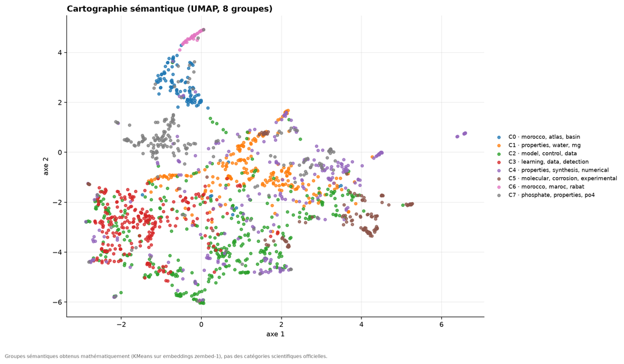

```
Version interactive : C:\Users\User\Desktop\DL\fsbm-semantic-publications\outputs\figures\semantic_map_clusters.html
```

```python
if vectors is not None and articles is not None and len(articles) >= 3:
    from src.analysis.semantic_map import build_semantic_map
    cfg = settings["semantic_map"]
    aligned = articles.set_index("article_id", drop=False).loc[manifest["article_id"]].reset_index(drop=True)
    res = build_semantic_map(aligned, vectors, links, researchers, FIG, REP, method=cfg["reduction"],
                             n_clusters=cfg["n_clusters"], k_range=tuple(cfg["k_range"]),
                             n_neighbors=cfg["umap_n_neighbors"], min_dist=cfg["umap_min_dist"],
                             random_state=settings["project"]["random_state"])
    print(res["info"])
    display(res["clusters"][["cluster", "n_publications", "top_terms", "titres_representatifs"]])
    display(Image(filename=res["paths"]["png_clusters"], width=800))
    print("Version interactive :", res["paths"]["html_clusters"])
```

## 17. Limites

- Google Scholar peut **modifier son HTML** ou limiter les requêtes ; en cas de blocage le pipeline s'arrête proprement et reprend plus tard (aucun contournement de CAPTCHA) ;
- les **citations évoluent** dans le temps : les valeurs correspondent à la date de collecte ;
- certaines métadonnées (abstract, DOI, date précise) peuvent être absentes ; l'aperçu Scholar est parfois tronqué (`abstract_status = truncated`) ;
- l'appariement de profils est probabiliste : les cas ambigus nécessitent une vérification humaine (`scholar_overrides.csv`) ;
- le plafond de publications par chercheur (`max_publications_per_researcher`) rend les classements **descriptifs du dataset collecté** ;
- les clusters dépendent de UMAP/KMeans et de l'échantillon : ce sont des regroupements sémantiques, pas des disciplines officielles ;
- l'ordre nom/prénom du PDF n'est pas déductible de façon fiable : les comparaisons de noms sont insensibles à l'ordre.

## 18. Conclusion

Le pipeline produit un dataset structuré et validé, un index vectoriel basé sur **zembed-1**, un moteur de recherche sémantique de publications et de chercheurs, et une cartographie des travaux — avec une traçabilité complète des valeurs manquantes.